# ML_PartIII_Regression

Julia Snyder

12/7/2021

## Machine Learning

#### 1. Regression Models to Predict Song Popularity

```r
library(tidyverse)
library(splitstackshape)
library(caret)
library(e1071)
library(MASS)
library(rpart)
library(randomForest)
library(knitr)
```

```r
data_clean <- readRDS("music_genre_clean.rds")
```

##### Popularity

Popularity is a continuous score ranging from 0-99 that reflects a song’s popularity.

```r
# Popularity as continuous outcome (Regression)
head(data_clean)
```

```
## # A tibble: 6 × 14
##   popularity acousticness danceability duration_ms energy instrumentalness key
##        <dbl>        <dbl>        <dbl>       <dbl>  <dbl>            <dbl> <fct>
## 1         31      0.0127         0.622      218293  0.89        0.95       D
## 2         28      0.00306        0.62       215613  0.755       0.0118     G#
## 3         34      0.0254         0.774      166875  0.7         0.00253    C#
## 4         32      0.00465        0.638      222369  0.587       0.909      F#
## 5         46      0.0289         0.572      214408  0.803       0.00000774 B
## 6         43      0.0297         0.809      416132  0.706       0.903      G
## # … with 7 more variables: liveness <dbl>, loudness <dbl>, mode <fct>,
## #   speechiness <dbl>, tempo <dbl>, valence <dbl>, music_genre <fct>
```

```r
summary(data_clean$popularity)
```

```
##    Min. 1st Qu.  Median    Mean 3rd Qu.    Max.
##    0.00   34.00   45.00   44.28   56.00   99.00
```

The Exploratory Data Analysis (EDA) included plots of the distribution of continuous and categorical variables and popularity. Potential predictors based on EDA: music genre, danceability, loudness, speechiness

##### Create training and test sets

```r
set.seed(1)

pop_train_index = createDataPartition(y = data_clean$popularity, times = 1, p = 0.7, list = FALSE)
pop_train_set = slice(data_clean, pop_train_index)
pop_test_set = slice(data_clean, -pop_train_index)

dim(pop_train_set)
```

```
## [1] 28394    14
```

```r
dim(pop_test_set)
```

```
## [1] 12166    14
```

##### kNN Model

```r
# Fit a k-nearest neighbors model
set.seed(1)
knn_fit_pop <- knn3(popularity ~ ., data=pop_train_set, k=7)

# Prediction for the test set
preds_pop <- predict(knn_fit_pop, newdata = pop_test_set)[,2]

# Performance metrics
knn_fit_pop
```

```
## 7-nearest neighbor model
## Training set outcome distribution:
##    Min. 1st Qu.  Median    Mean 3rd Qu.    Max.
##    0.00   34.00   45.00   44.25   56.00   99.00
```

```r
summary(knn_fit_pop)
```

```
##         Length Class  Mode
## learn   2      -none- list
## k       1      -none- numeric
## terms   3      terms  call
## xlevels 3      -none- list
## theDots 0      -none- list
```

```r
mse_knn <- mean((preds_pop - pop_test_set$popularity)^2)
mse_knn
```

```
## [1] 2208.143
```

```r
rmse_knn <- RMSE(preds_pop, pop_test_set$popularity)
rmse_knn
```

```
## [1] 46.99088
```

The square root of the MSE is 46.99, indicating this model leads to test predictions that are within approximately 46.99 points of the true popularity score. This model has a lot of error in predicting song popularity.

##### Decision Tree Model

```r
# Fit a decision tree model
set.seed(1)
rpart_fit_pop <- rpart(popularity ~ ., data=pop_train_set)


# Use tree for prediction
pred_rpart_pop <- predict(rpart_fit_pop, newdata = pop_test_set)
test_rpart <- pop_test_set$popularity

# Performance metrics
rpart_fit_pop
```

```
## n= 28394
##
## node), split, n, deviance, yval
##       * denotes terminal node
##
## 1) root 28394 6851076.0 44.25129
##   2) music_genre=Anime,Blues,Classical,Electronic,Jazz 14121 2137690.0 33.50081
##     4) music_genre=Anime,Classical 5649  865772.3 26.66401 *
##     5) music_genre=Blues,Electronic,Jazz 8472  831812.0 38.05949 *
##   3) music_genre=Alternative,Country,Hip-Hop,Rap,Rock 14273 1466764.0 54.88727
##     6) music_genre=Alternative,Country 5710  471783.2 48.03923 *
##     7) music_genre=Hip-Hop,Rap,Rock 8563  548648.4 59.45370 *
```

```r
summary(rpart_fit_pop)
```

```
## Call:
## rpart(formula = popularity ~ ., data = pop_train_set)
##   n= 28394
##
##           CP nsplit rel error    xerror        xstd
## 1 0.47388500      0 1.0000000 1.0000789 0.008466224
## 2 0.06514772      1 0.5261150 0.5261640 0.005574914
## 3 0.06423895      2 0.4609673 0.4622909 0.005208715
## 4 0.01000000      3 0.3967283 0.3968143 0.004475283
##
## Variable importance
##      music_genre instrumentalness         loudness     acousticness
##               41               15               12               11
##           energy     danceability          valence      speechiness
##               10               10                1                1
##
## Node number 1: 28394 observations,    complexity param=0.473885
##   mean=44.25129, MSE=241.286
##   left son=2 (14121 obs) right son=3 (14273 obs)
##   Primary splits:
##       music_genre      splits as  RLLLRLRLRR,   improve=0.4738850, (0 missing)
##       instrumentalness < 0.1325   to the right, improve=0.1252788, (0 missing)
##       loudness         < -14.7945 to the left,  improve=0.1156708, (0 missing)
##       acousticness     < 0.8565   to the right, improve=0.1106514, (0 missing)
##       energy           < 0.2725   to the left,  improve=0.1048920, (0 missing)
##   Surrogate splits:
##       instrumentalness < 0.001355 to the right, agree=0.735, adj=0.468, (0 split)
##       loudness         < -9.578   to the left,  agree=0.663, adj=0.322, (0 split)
##       acousticness     < 0.5735   to the right, agree=0.644, adj=0.284, (0 split)
##       energy           < 0.4145   to the left,  agree=0.634, adj=0.264, (0 split)
##       danceability     < 0.4925   to the left,  agree=0.626, adj=0.248, (0 split)
##
## Node number 2: 14121 observations,    complexity param=0.06423895
##   mean=33.50081, MSE=151.3838
##   left son=4 (5649 obs) right son=5 (8472 obs)
##   Primary splits:
##       music_genre  splits as  -LRL-R-R--,   improve=0.20587920, (0 missing)
##       loudness     < -16.4375 to the left,  improve=0.03798253, (0 missing)
##       danceability < 0.5665   to the left,  improve=0.03519357, (0 missing)
##       acousticness < 0.9085   to the right, improve=0.03167178, (0 missing)
```

[output cut: 20 more lines]

```
##       energy       < 0.9405   to the right, agree=0.612, adj=0.029, (0 split)
##       acousticness < 0.6525   to the right, agree=0.609, adj=0.024, (0 split)
##       liveness     < 0.8935   to the right, agree=0.602, adj=0.005, (0 split)
##
## Node number 4: 5649 observations
##   mean=26.66401, MSE=153.2612
##
## Node number 5: 8472 observations
##   mean=38.05949, MSE=98.18367
##
## Node number 6: 5710 observations
##   mean=48.03923, MSE=82.62403
##
## Node number 7: 8563 observations
##   mean=59.4537, MSE=64.07198
```

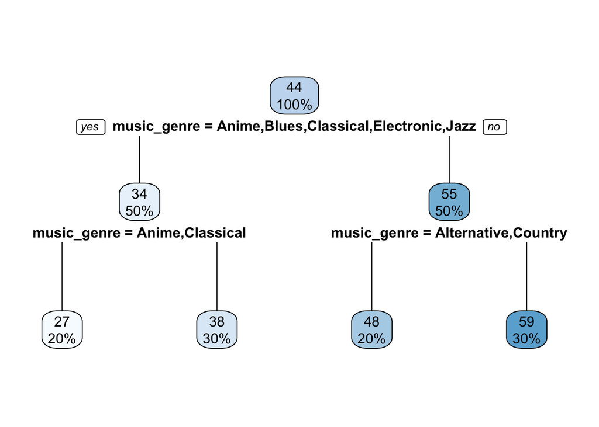

```r
rpart.plot::rpart.plot(rpart_fit_pop)
```

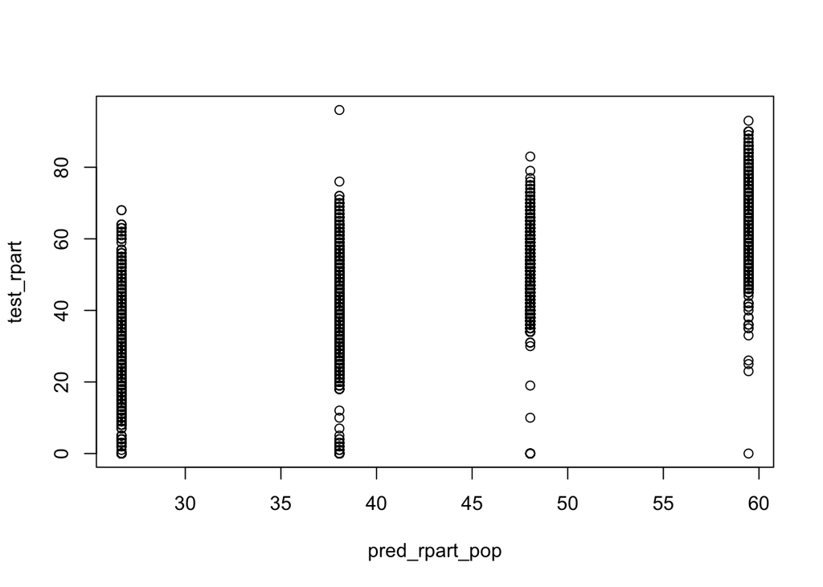

```r
plot(pred_rpart_pop, test_rpart)
```

```r
mse_rpart <- mean((pred_rpart_pop - pop_test_set$popularity)^2)
mse_rpart
```

```
## [1] 96.03859
```

```r
rmse_rpart <- RMSE(pred_rpart_pop, pop_test_set$popularity)
rmse_rpart
```

```
## [1] 9.799928
```

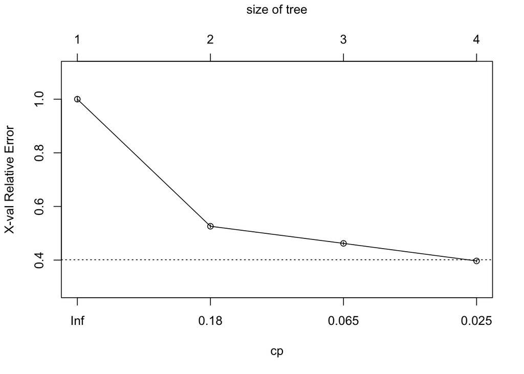

```r
# Trying pruning tree
plotcp(rpart_fit_pop)
```

```r
p <- prune(rpart_fit_pop, cp = 0.025)
preds_prune <- predict(p, newdata = pop_test_set)
mean((preds_prune - pop_test_set$popularity)^2)
```

```
## [1] 96.03859
```

Music genre was the predictor that minimized the error the most. The test set MSE for this tree is 96.04. The square root of the MSE is 9.8, indicating this model leads to test predictions that are within approximately 9.8 points of the true popularity score. Pruning did not improve the MSE.

##### Random Forest Model

```r
# Fit a random forest model
set.seed(1)
rf_fit_pop <- randomForest(popularity ~ ., data=pop_train_set, ntree=100, mtry=3, importance = TRUE)

# Prediction for the test set
pred_rf_pop <- predict(rf_fit_pop, newdata = pop_test_set)
test_rf <- pop_test_set$popularity

# Performance metrics
rf_fit_pop
```

```
##
## Call:
##  randomForest(formula = popularity ~ ., data = pop_train_set,      ntree = 100, mtry = 3, importance = TRUE)
##                Type of random forest: regression
##                      Number of trees: 100
## No. of variables tried at each split: 3
##
##           Mean of squared residuals: 86.01896
##                     % Var explained: 64.35
```

```r
summary(rf_fit_pop)
```

```
##                 Length Class  Mode
## call                6  -none- call
## type                1  -none- character
## predicted       28394  -none- numeric
## mse               100  -none- numeric
## rsq               100  -none- numeric
## oob.times       28394  -none- numeric
## importance         26  -none- numeric
## importanceSD       13  -none- numeric
## localImportance     0  -none- NULL
## proximity           0  -none- NULL
## ntree               1  -none- numeric
## mtry                1  -none- numeric
## forest             11  -none- list
## coefs               0  -none- NULL
## y               28394  -none- numeric
## test                0  -none- NULL
## inbag               0  -none- NULL
## terms               3  terms  call
```

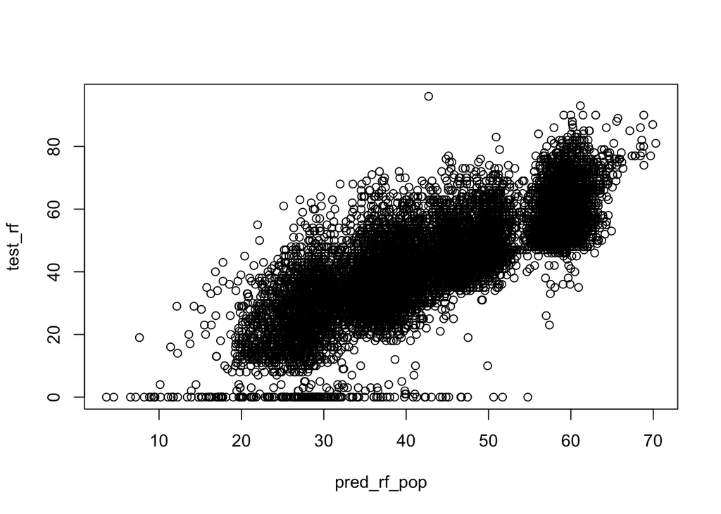

```r
plot(pred_rf_pop, test_rf)
```

```r
mse_rf <- mean((pred_rf_pop - pop_test_set$popularity)^2)
mse_rf
```

```
## [1] 83.40155
```

```r
rmse_rf <- RMSE(pred_rf_pop, pop_test_set$popularity)
rmse_rf
```

```
## [1] 9.132445
```

```r
#Variable Importance
variable_importance <- importance(rf_fit_pop)
tmp <- tibble(feature = rownames(variable_importance), Gini = variable_importance[,1])
tmp
```

```
## # A tibble: 13 × 2
##    feature           Gini
##    <chr>            <dbl>
##  1 acousticness     15.8
##  2 danceability     16.7
##  3 duration_ms      15.1
##  4 energy           22.7
##  5 instrumentalness 23.7
##  6 key               8.10
##  7 liveness         19.1
##  8 loudness         20.1
##  9 mode              3.39
## 10 speechiness      20.5
## 11 tempo            15.1
## 12 valence          21.6
## 13 music_genre      77.5
```

##### Selected Features Random Forest Model

```r
# Fit a random forest model
set.seed(1)
rf_fit_pop2 <- randomForest(popularity ~ music_genre + instrumentalness + valence + energy + loudness + liveness + duration_ms + danceability, data=pop_train_set, ntree=100, mtry=3, importance = TRUE)


# Prediction for the test set
pred_rf_pop2 <- predict(rf_fit_pop2, newdata = pop_test_set)
test_rf2 <- pop_test_set$popularity

# Performance metrics
rf_fit_pop2
```

```
##
## Call:
##  randomForest(formula = popularity ~ music_genre + instrumentalness +      valence + energy + loudness + liveness + duration_ms + danceability,      data = pop_train_set, ntree = 100, mtry = 3, importance = TRUE)
##                Type of random forest: regression
##                      Number of trees: 100
## No. of variables tried at each split: 3
##
##           Mean of squared residuals: 87.71636
##                     % Var explained: 63.65
```

```r
summary(rf_fit_pop2)
```

```
##                 Length Class  Mode
## call                6  -none- call
## type                1  -none- character
## predicted       28394  -none- numeric
## mse               100  -none- numeric
## rsq               100  -none- numeric
## oob.times       28394  -none- numeric
## importance         16  -none- numeric
## importanceSD        8  -none- numeric
## localImportance     0  -none- NULL
## proximity           0  -none- NULL
## ntree               1  -none- numeric
## mtry                1  -none- numeric
## forest             11  -none- list
## coefs               0  -none- NULL
## y               28394  -none- numeric
## test                0  -none- NULL
## inbag               0  -none- NULL
## terms               3  terms  call
```

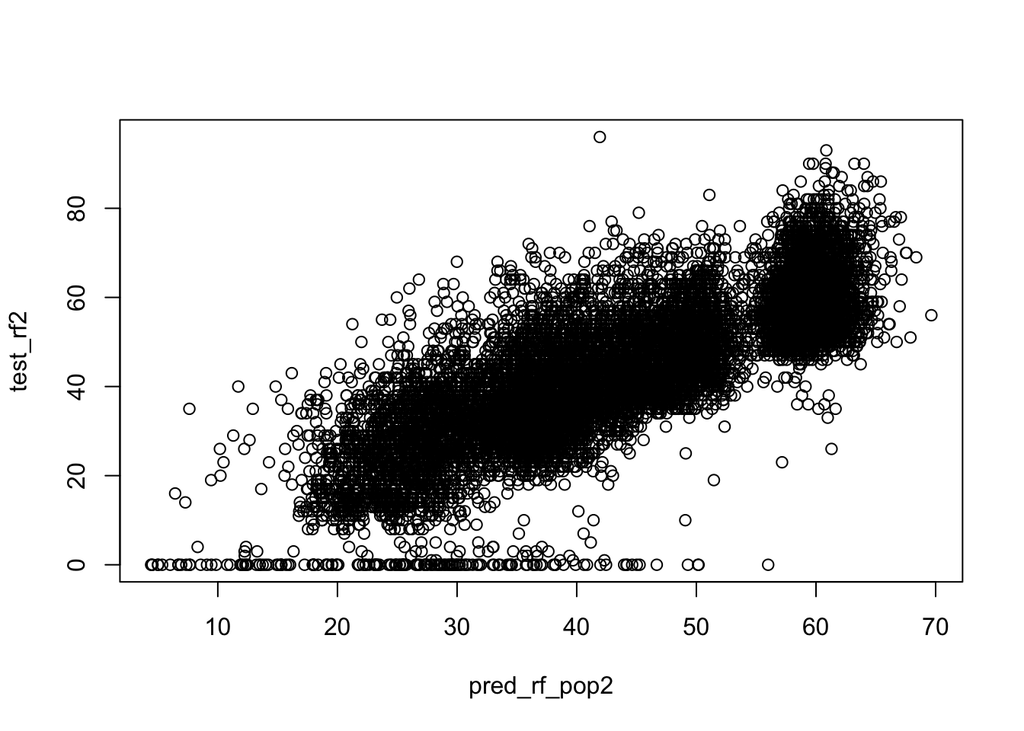

```r
plot(pred_rf_pop2, test_rf2)
```

```r
mse_rf <- mean((pred_rf_pop2 - pop_test_set$popularity)^2)
mse_rf
```

```
## [1] 85.53812
```

```r
rmse_rf2 <- RMSE(pred_rf_pop2, pop_test_set$popularity)
rmse_rf
```

```
## [1] 9.132445
```

##### Model Comparisons

```r
rmse_results <- data.frame(Model = c("kNN", "Decision Tree", "Random Forest"), RMSE = c(rmse_knn, rmse_rpart, rmse_rf))
rmse_results
```

```
##           Model      RMSE
## 1           kNN 46.990884
## 2 Decision Tree  9.799928
## 3 Random Forest  9.132445
```

The random forest model performed the best.